# Reproducible Research: Peer Assessment 1

This summary shows various analyses of a dataset that contains the number of steps taken by a single user who’s wearing a tracking device. Steps are measured every 5 minutes, over a 2 month period.

## Loading and preprocessing the data

This step:  
- loads the ggplot2 package  
- reads in the dataset  
- converts the date field into a date format

```r
library(ggplot2)
data <- read.csv("activity.csv")
data$date <- as.Date(data$date)
```

## What is mean total number of steps taken per day?

Here is a histogram showing the frequency of how many steps are taken in a day.

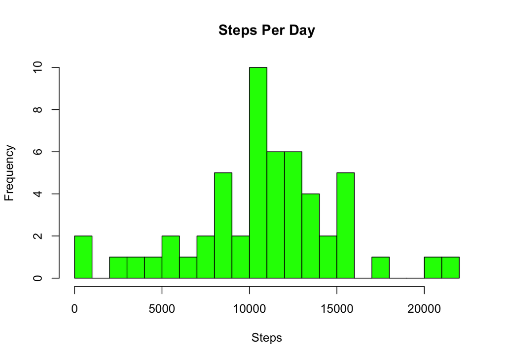

```r
histdata <- aggregate(data$steps, list(date = data$date), sum)
colnames(histdata)[2] <- "steps"
hist(histdata$steps, breaks = 20, main = "Steps Per Day", xlab = "Steps", col = "green")
```

The mean and median number of steps taken in a day is:

```r
mean(histdata$steps, na.rm=TRUE)
```

```
## [1] 10766.19
```

```r
median(histdata$steps, na.rm=TRUE)
```

```
## [1] 10765
```

## What is the average daily activity pattern?

Here is a time series plot showing the average number of steps taken in each 5 minute interval throughout the day:

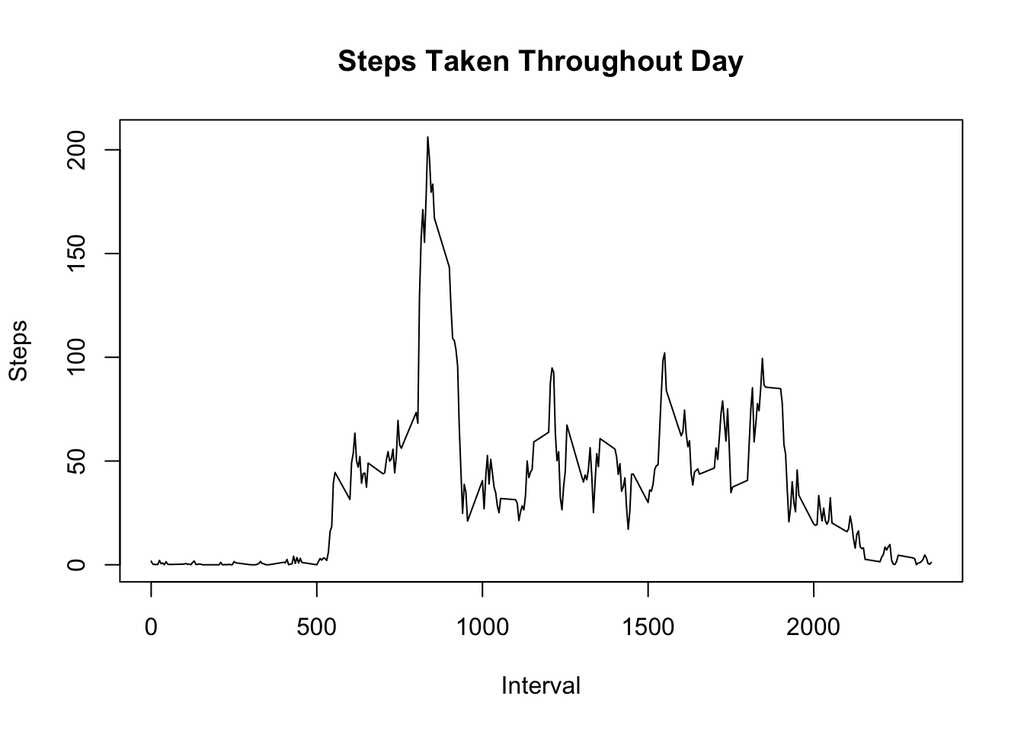

```r
timedata <- aggregate(data$steps, list(Interval = data$interval), mean, na.rm=TRUE)
colnames(timedata)[2] <- "steps"
plot(timedata, type="l", main = "Steps Taken Throughout Day", ylab = "Steps")
```

The 5 minute interval with the highest average of steps taken throughout the day (and the mean number of steps in that interval) is:

```r
timedata[which.max(timedata$steps),]
```

```
##     Interval    steps
## 104      835 206.1698
```

## Imputing missing values

The number of observations in the data are:

```r
nrow(data)
```

```
## [1] 17568
```

The number of observations that don’t have a step count are:

```r
sum(is.na(data))
```

```
## [1] 2304
```

This step creates a 2nd dataset where each of the missing step counts are imputed with the average number of steps in that interval.

```r
data2 <- data
data2$steps[is.na(data2$steps)] = timedata$steps
```

Here is a histogram showing the frequency of steps taken in a day (same as previous histogram, but with missing values imputed):

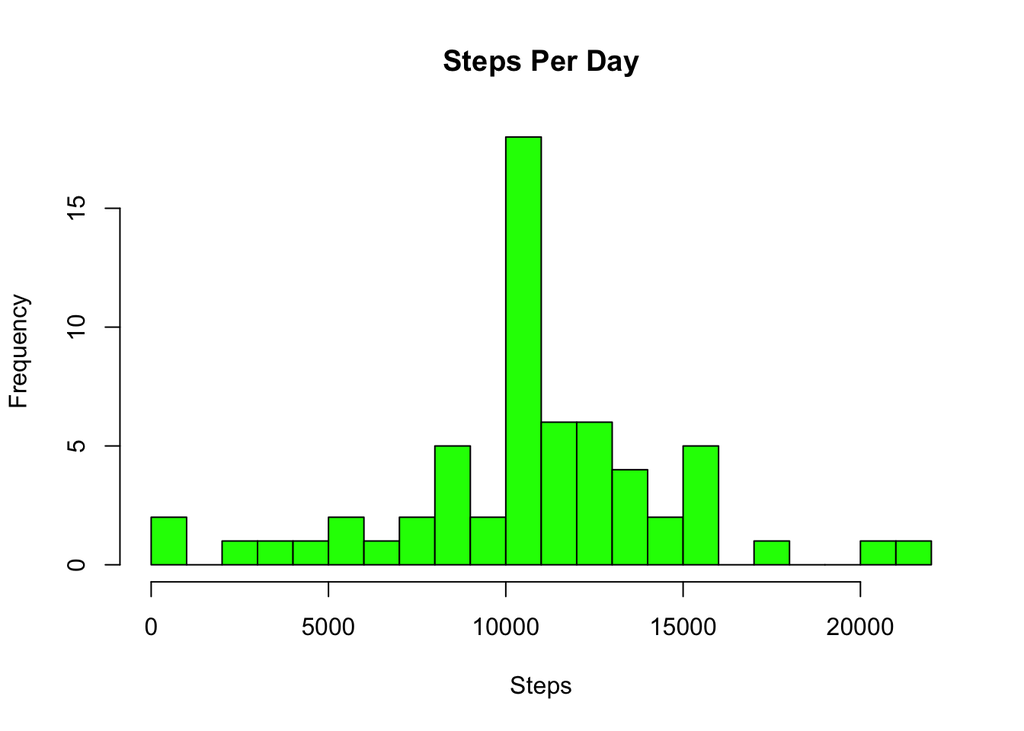

```r
histdata2 <- aggregate(data2$steps, list(date = data$date), sum)
colnames(histdata2)[2] <- "steps"
hist(histdata2$steps, breaks = 20, main = "Steps Per Day", xlab = "Steps", col = "green")
```

And the mean and median of the step count per day (using the dataset with imputed data) are:

```r
mean(histdata2$steps)
```

```
## [1] 10766.19
```

```r
median(histdata2$steps)
```

```
## [1] 10766.19
```

## Are there differences in activity patterns between weekdays and weekends?

We first need to create a new variable in the dataset that indicates if a date is a weekday or weekend.

```r
data2$weekday <- weekdays(data2$date)
data2$daytype <- ifelse(data2$weekday %in% c("Saturday","Sunday"),"Weekend", "Weekday")
```

Here is a panel plot that shows the average step count in each 5 minute interval throughout the day, separating weekday and weekend data in separate panels.

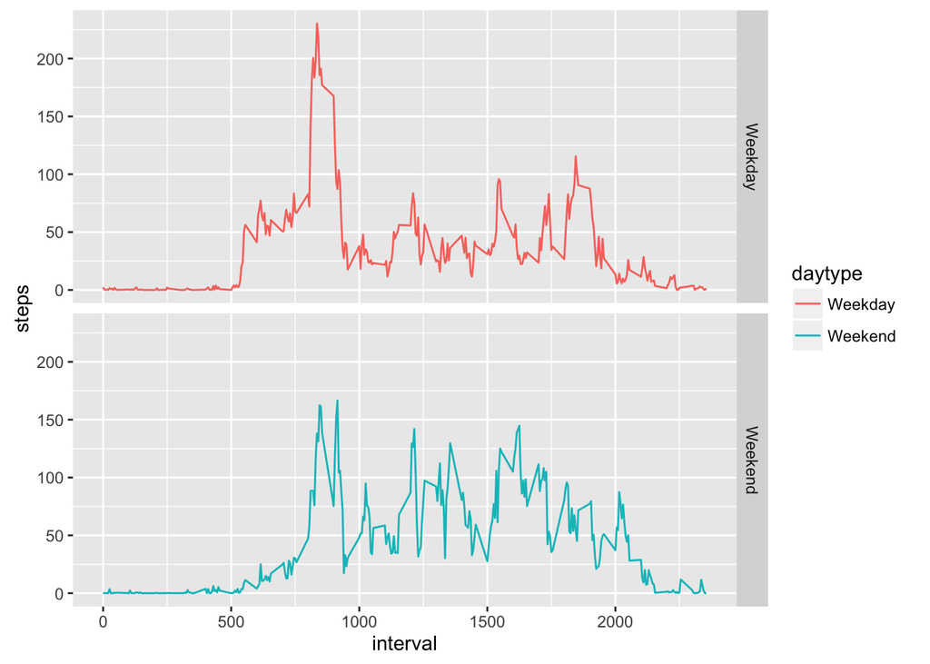

```r
timedata2 <- aggregate(data2$steps, list(data2$interval, data2$daytype), mean)
colnames(timedata2) <- c("interval", "daytype","steps")
plot <- ggplot(data=timedata2, aes(x=interval, y=steps, group=daytype, color=daytype))
plot + geom_line() + facet_grid(daytype~.)
```